# Econometria Aplicada à Finanças Aula 8

## A matriz $X$ de `PublicSchools`

Na Aula 7, vimos que a fórmula de um modelo `lm` é convertida em sua **matriz do modelo**.

```r
# extrai a matriz X do modelo estimado
X <- model.matrix(ps_lm)

# verifica suas dimensões e colunas
dim(X)
```

```
[1] 50  2
```

```r
colnames(X)
```

```
[1] "(Intercept)" "Income"
```

A matriz $X$ possui:

- **50 linhas**: $n=50$ observações;
- **2 colunas**: o intercepto e `Income`.

Portanto, $p=1$ e $p+1=2$.

## Calculando a matriz $H$ em R

Podemos reproduzir a expressão

$$H=X(X'X)^{-1}X'$$

com as operações matriciais estudadas na Aula 7.

```r
# calcula X'X
XtX <- crossprod(X)

# calcula a inversa de X'X
XtX_inv <- solve(XtX)

# calcula a matriz H
H <- X %*% XtX_inv %*% t(X)

# extrai os elementos diagonais de H
hii_matriz <- diag(H)

head(hii_matriz)
```

```
   Alabama     Alaska    Arizona   Arkansas California   Colorado
  0.054274   0.214373   0.021017   0.057572   0.048493   0.022847
```

## Calculando a matriz $H$ em R

Para analisar a alavancagem, não precisamos examinar toda a matriz $H$: interessam seus elementos diagonais, $h_{ii}$.

O cálculo explícito de $H$ torna visível a relação entre a expressão matricial e sua implementação com R.

## Alavancagem com `hatvalues()`

Para um modelo estimado com `lm()`, o R fornece diretamente os valores de alavancagem:

```r
# calcula diretamente os valores de alavancagem
hii <- hatvalues(ps_lm)

head(hii)
```

```
   Alabama     Alaska    Arizona   Arkansas California   Colorado
  0.054274   0.214373   0.021017   0.057572   0.048493   0.022847
```

Podemos verificar que são os mesmos valores obtidos pela diagonal da matriz $H$:

```r
all.equal(hii_matriz, hii)
```

```
[1] TRUE
```

Não são dois diagnósticos diferentes: `hatvalues()` fornece diretamente os mesmos valores $h_{ii}$.

## Referência prática em `PublicSchools`

Para este modelo,

$$n=50,
\qquad
p=1,
\qquad
p+1=2.$$

Podemos calcular a referência de triagem diretamente no R:

```r
# número de observações e de variáveis explicativas
n <- nrow(X)
p <- ncol(X) - 1

# referência para alta alavancagem
limite_h <- 2 * (p + 1) / n

limite_h
```

```
[1] 0.08
```

Assim,

$$\frac{2(p+1)}{n} = \frac{2(2)}{50} = 0{,}08.$$

## Alavancagem em `PublicSchools`

Podemos associar os valores de alavancagem às respectivas observações:

```r
# organiza os valores de alavancagem por observação
alavancagem_ps <- tibble(
  Observação = names(hii),
  Alavancagem = as.numeric(hii)
)

# identifica as observações acima da referência
alavancagem_ps |>
  filter(Alavancagem > limite_h) |>
  arrange(desc(Alavancagem))
```

```
# A tibble: 3 × 2
  Observação    Alavancagem
  <chr>               <dbl>
1 Alaska             0.214
2 Washington DC      0.128
3 Mississippi        0.0848
```

O código aplica diretamente a regra

$$h_{ii}>0{,}08$$

a todas as observações da amostra.

## Alavancagem: Alaska e Mississippi

Dois casos serão particularmente úteis quando compararmos os diferentes diagnósticos:

| Observação | $h_{ii}$ |
| --- | --- |
| Alaska | 0.2144 |
| Mississippi | 0.0848 |

- **Alaska:** $h_{ii}\approx0{,}2144$;
- **Mississippi:** $h_{ii}\approx0{,}0848$.

Ambas ultrapassam a referência de $0{,}08$.

Alta alavancagem, isoladamente, não estabelece que uma observação seja influente.

## Variância dos resíduos

Sob as hipóteses de homocedasticidade e ausência de correlação entre os erros (Kleiber e Zeileis, 2008):

$$\operatorname{Var}(\varepsilon\mid X)=\sigma^2I.$$

Como $y=X\beta+\varepsilon$ e $HX=X$,

$$(I-H)X=0.$$

Portanto, $\hat e = y-\hat y = (I-H)y = (I-H)\varepsilon$:

Como $H$ é simétrica e idempotente,

$$(I-H)(I-H)'=I-H.$$

Assim,

$$\begin{aligned}
\operatorname{Var}(\hat e\mid X)
&=
(I-H)\operatorname{Var}(\varepsilon\mid X)(I-H)'\\
&=
\sigma^2(I-H).
\end{aligned}$$

Para a observação $i$,

$$\boxed{
\operatorname{Var}(\hat e_i\mid X)
=
\sigma^2(1-h_{ii})
}$$

Os resíduos de observações com diferentes valores de alavancagem não têm a mesma variância.

## Resíduos padronizados

Vimos que, sob as hipóteses usuais,

$$\operatorname{Var}(\hat e_i\mid X)
=
\sigma^2(1-h_{ii}).$$

Portanto,

$$\operatorname{sd}(\hat e_i\mid X)
=
\sigma\sqrt{1-h_{ii}}.$$

Como $\sigma$ é desconhecido, usamos sua estimativa $\hat\sigma$ e definimos o **resíduo padronizado**:

$$\boxed{
r_i
=
\frac{\hat e_i}
{\hat\sigma\sqrt{1-h_{ii}}}
}$$

- $\hat e_i$ mede o afastamento entre $y_i$ e $\hat y_i$;
- $\sqrt{1-h_{ii}}$ ajusta a escala do resíduo à sua alavancagem;
- $\hat\sigma$ estima o desvio-padrão dos erros usando a amostra completa.

Assim, resíduos com variabilidades diferentes podem ser comparados em uma escala comum.

## Resíduos studentizados

No resíduo padronizado,

$$r_i
=
\frac{\hat e_i}
{\hat\sigma\sqrt{1-h_{ii}}},$$

a estimativa $\hat\sigma$ utiliza **todas as observações**, inclusive a observação $i$ que estamos avaliando.

Uma observação incomum pode também afetar a estimação de $\sigma$.

Para evitar que a própria observação participe da estimação da escala usada para avaliá-la, estimamos $\sigma$ novamente **sem a observação $i$**:

$$\hat\sigma_{(i)}.$$

Obtemos então o **resíduo studentizado externamente** (Hill, Griffiths e Lim, 2018):

$$\boxed{
r_i^*
=
\frac{\hat e_i}
{\hat\sigma_{(i)}\sqrt{1-h_{ii}}}
}$$

## Resíduo padronizado × resíduo studentizado

Compare as duas expressões:

$$r_i
=
\frac{\hat e_i}
{\hat\sigma\sqrt{1-h_{ii}}}
\qquad\text{e}\qquad
r_i^*
=
\frac{\hat e_i}
{\hat\sigma_{(i)}\sqrt{1-h_{ii}}}.$$

Nos dois casos:

- o numerador é o mesmo resíduo, $\hat e_i$;
- a alavancagem é considerada pelo mesmo fator, $\sqrt{1-h_{ii}}$.

A diferença está na estimação da escala dos erros:

$$\underbrace{\hat\sigma}_{\text{inclui a observação }i}
\qquad\text{versus}\qquad
\underbrace{\hat\sigma_{(i)}}_{\text{exclui a observação }i}.$$

No resíduo studentizado externamente, a observação é avaliada usando uma estimativa de $\sigma$ da qual ela própria não participou.

## Resíduos studentizados em R

No R, `rstandard()` e `rstudent()` implementam os dois procedimentos:

```r
# resíduos padronizados
rpad <- rstandard(ps_lm)

# resíduos studentizados externamente
rstud <- rstudent(ps_lm)

# compara os primeiros valores
head(
  cbind(
    Padronizado = rpad,
    Studentizado = rstud
  )
)
```

```
           Padronizado Studentizado
Alabama    -0.07360471  -0.07283807
Alaska      4.11917243   5.06933614
Arizona    -0.29771944  -0.29487426
Arkansas    0.00027532   0.00027243
California -1.19934475  -1.20497809
Colorado    0.85143573   0.84895519
```

Uma referência prática é investigar observações para as quais

$$|r_i^*|>2.$$

Essa é uma regra de triagem, não um teste formal nem uma regra automática de exclusão.

## Resíduos studentizados em `PublicSchools`

Para Alaska,

$$r_i \approx 4{,}12
\qquad\text{e}\qquad
r_i^* \approx 5{,}07.$$

Como $\hat e_i$ e $h_{ii}$ são os mesmos, a diferença decorre de $\hat\sigma$ e $\hat\sigma_{(i)}$.

Sem Alaska, a estimativa da escala dos erros diminui e seu resíduo studentizado se torna ainda mais extremo.

Aplicando a referência $|r_i^*|>2$ a todas as observações:

```r
# associa cada resíduo studentizado à sua observação
residuos_studentizados <- tibble(
  Observação = names(rstud),
  `Resíduo studentizado` = as.numeric(rstud)
)

# identifica as observações com |r_i^*| > 2
residuos_studentizados |>
  filter(abs(`Resíduo studentizado`) > 2) |>
  arrange(desc(abs(`Resíduo studentizado`)))
```

```
# A tibble: 2 × 2
  Observação    `Resíduo studentizado`
  <chr>                          <dbl>
1 Alaska                          5.07
2 Washington DC                  -2.01
```

Alaska e Washington DC são sinalizadas por $|r_i^*|>2$. Esse diagnóstico identifica resíduos incomuns; não mede, por si só, a influência sobre a regressão.

## Influência

Até aqui, avaliamos duas características diferentes de uma observação:

- o resíduo studentizado, $r_i^*$, indica quão incomum é $y_i$ em relação ao valor ajustado pelo modelo;
- a alavancagem, $h_{ii}$, indica quão incomuns são os valores das variáveis explicativas da observação em relação aos demais valores da amostra.

Nenhuma dessas medidas avalia diretamente **quanto os coeficientes estimados ou os valores ajustados mudam quando a observação é retirada**.

Para avaliar influência, retomamos a estratégia *delete-one*: excluímos a observação, reestimamos o modelo e comparamos os resultados com os obtidos usando a amostra completa.

## Medidas de influência

Há diferentes medidas para avaliar como uma observação afeta uma regressão quando é excluída.

Nesta aula, vamos nos concentrar em duas:

- **DFBETAS:** mede a mudança em cada coeficiente estimado;
- **DFFITS:** mede a mudança no valor ajustado.

Como os coeficientes são nossos principais objetos de interesse, **DFBETAS fornece o diagnóstico mais direto de sua sensibilidade**.

Mas o DFFITS acrescenta outra informação: mostra a consequência conjunta das mudanças nos coeficientes para o ajuste da regressão.

Isso ocorre porque

$$\hat y_i-\hat y_{i,(i)}
=
\mathbf{x}_i'
\left(
\hat\beta-\hat\beta_{(i)}
\right).$$

DFBETAS mostra quais coeficientes mudam; DFFITS mostra o efeito conjunto dessas mudanças sobre o valor ajustado.

## DFBETAS

Como os coeficientes são nossos principais objetos de interesse, começamos avaliando diretamente sua sensibilidade à exclusão de uma observação.

> **Quanto a estimativa de cada coeficiente muda quando excluímos a observação $i$?**

Para o coeficiente $\beta_j$,

$$\boxed{
\mathrm{DFBETAS}_{j(i)}
=
\frac{
\hat\beta_j-\hat\beta_{j(i)}
}{
\hat\sigma_{(i)}\sqrt{c_{jj}}
}
}$$

em que $c_{jj}$ é o elemento diagonal correspondente de $(X'X)^{-1}$.

O DFBETAS é específico por coeficiente: uma observação pode alterar substantivamente uma estimativa e pouco outra.

## DFBETAS em R

No R, `dfbetas()` calcula o diagnóstico para cada observação e para cada coeficiente do modelo:

```r
# calcula DFBETAS para cada observação e coeficiente
dfbetas_ps <- dfbetas(ps_lm)

head(dfbetas_ps)
```

```
           (Intercept)       Income
Alabama    -0.01517309  0.013866241
Alaska     -2.38873017  2.521512287
Arizona    -0.01512571  0.009504942
Arkansas    0.00005927 -0.000054396
California  0.18293634 -0.208518783
Colorado   -0.02895495  0.045827169
```

Uma referência prática para cada coeficiente é (Hill, Griffiths e Lim, 2018)

$$|\mathrm{DFBETAS}_{j(i)}|
>
\frac{2}{\sqrt n}.$$

Para `PublicSchools`:

```r
# calcula a referência prática
limite_dfbetas <- 2 / sqrt(n)

limite_dfbetas
```

```
[1] 0.28284
```

Valores que ultrapassam essa referência indicam coeficientes particularmente sensíveis à presença da observação.

## DFBETAS em `PublicSchools`

Para observar como o diagnóstico pode diferir entre coeficientes, compare Alaska e Utah:

```r
dfbetas_ps[c("Alaska", "Utah"), ]
```

```
       (Intercept)   Income
Alaska    -2.38873  2.52151
Utah       0.29543 -0.26062
```

Para estes dados,

$$\frac{2}{\sqrt n}\approx 0{,}283.$$

- **Alaska:** ultrapassa a referência tanto para o intercepto quanto para `Income`;
- **Utah:** ultrapassa a referência para o intercepto, mas não para `Income`.

Uma observação pode ser influente para um coeficiente e não para outro.

## DFFITS

O DFFITS mede quanto o **valor ajustado para a observação $i$** muda quando essa observação é excluída da estimação (Hill, Griffiths e Lim, 2018).

Defina

$$\hat y_{i,(i)}
=
\mathbf{x}_i'\hat\beta_{(i)},$$

isto é, o valor ajustado para a observação $i$ usando os coeficientes estimados **sem essa observação**.

O DFFITS compara esse valor com o obtido usando a amostra completa:

$$\boxed{
\mathrm{DFFITS}_i
=
\frac{
\hat y_i-\hat y_{i,(i)}
}{
\hat\sigma_{(i)}\sqrt{h_{ii}}
}
}$$

Quanto maior $|\mathrm{DFFITS}_i|$, maior a mudança no valor ajustado associada à presença da observação $i$.

## DFFITS, resíduo e alavancagem

O DFFITS também pode ser escrito como (Hill, Griffiths e Lim, 2018)

$$\boxed{
\mathrm{DFFITS}_i
=
\sqrt{\frac{h_{ii}}{1-h_{ii}}}\;r_i^*
}$$

- $r_i^*$ representa a **discrepância** da observação em relação ao ajuste;
- $h_{ii}$ representa sua **alavancagem**;
- o DFFITS combina essas informações para medir a alteração no **valor ajustado**.

Assim, $|\mathrm{DFFITS}_i|$ tende a ser maior quando a observação apresenta um resíduo studentizado grande, alta alavancagem ou ambos.

Uma referência prática é

$$|\mathrm{DFFITS}_i|
>
2\sqrt{\frac{p+1}{n}}.$$

## DFFITS em R

No R, `dffits()` calcula o diagnóstico para cada observação:

```r
# calcula o DFFITS de cada observação
dffits_ps <- dffits(ps_lm)

head(dffits_ps)
```

```
     Alabama       Alaska      Arizona     Arkansas   California     Colorado
-0.017449061  2.648061977 -0.043205259  0.000067335 -0.272028523  0.129813947
```

Para `PublicSchools`, calculamos a referência de triagem:

```r
# calcula a referência prática
limite_dffits <- 2 * sqrt((p + 1) / n)

limite_dffits
```

```
[1] 0.4
```

E identificamos as observações que ultrapassam essa referência:

```r
# identifica observações sinalizadas pelo DFFITS
dffits_ps[abs(dffits_ps) > limite_dffits]
```

```
       Alaska        Nevada Washington DC
      2.64806      -0.47864      -0.76783
```

## Diagnósticos em `PublicSchools`

| Observação | $r_i^*$ | $h_{ii}$ | DFBETAS $\beta_0$ | DFBETAS `Income` | DFFITS |
| --- | --- | --- | --- | --- | --- |
| Alaska | 5.0693 | 0.2144 | -2.3887 | 2.5215 | 2.6481 |
| Mississippi | 0.2500 | 0.0848 | 0.0709 | -0.0665 | 0.0761 |
| Nevada | -1.9385 | 0.0575 | 0.3447 | -0.3865 | -0.4786 |
| Utah | 1.9055 | 0.0380 | 0.2954 | -0.2606 | 0.3787 |

Referências de triagem:

$$|r_i^*|>2,
\qquad
h_{ii}>0{,}08,
\qquad
|\mathrm{DFBETAS}|>0{,}2828,
\qquad
|\mathrm{DFFITS}|>0{,}40.$$

## Comparação dos diagnósticos

- **Alaska:** combina resíduo muito incomum, alta alavancagem e forte influência.
- **Mississippi:** possui alta alavancagem e resíduo pequeno; DFBETAS e DFFITS permanecem abaixo das referências de triagem.
- **Nevada:** não ultrapassa as referências de resíduo studentizado nem de alavancagem, mas DFBETAS e DFFITS a sinalizam.
- **Utah:** DFBETAS sinaliza o intercepto, mas não `Income`; DFFITS permanece abaixo da referência.

Não há um único diagnóstico suficiente: uma observação pode ser incomum em uma dimensão e não em outra. Os diagnósticos devem ser interpretados conjuntamente.

## Mascaramento

Quando há várias observações incomuns, elas podem **mascarar umas às outras** (*masking*) (Kleiber e Zeileis, 2008).

Isso significa que a presença conjunta de vários casos pode fazer com que os diagnósticos convencionais **não revelem claramente algumas observações problemáticas**.

Por isso, se uma observação for retirada por uma razão substantivamente justificada, é importante **reestimar o modelo e recalcular os diagnósticos**.

Mascaramento é uma limitação dos diagnósticos de exclusão, não uma justificativa para remover observações automaticamente.

## Análise de sensibilidade: Alaska

Alaska é sinalizada pelos diferentes diagnósticos de influência.

Podemos observar diretamente o que acontece quando retiramos essa observação:

```r
# remove Alaska da amostra
ps_sem_alaska <- ps |>
  as_tibble(rownames = "Observação") |>
  filter(Observação != "Alaska")

# reestima o modelo sem Alaska
ps_lm_sem_alaska <- lm(
  Expenditure ~ Income,
  data = ps_sem_alaska
)

# compara os coeficientes estimados
cbind(
  `Amostra completa` = coef(ps_lm),
  `Sem Alaska` = coef(ps_lm_sem_alaska)
)
```

```
            Amostra completa Sem Alaska
(Intercept)      -151.265090 -26.804488
Income              0.068939   0.051831
```

Estamos aplicando diretamente a estratégia *delete-one*:

$$\text{remover}
\longrightarrow
\text{reestimar}
\longrightarrow
\text{comparar}.$$

## Análise de sensibilidade

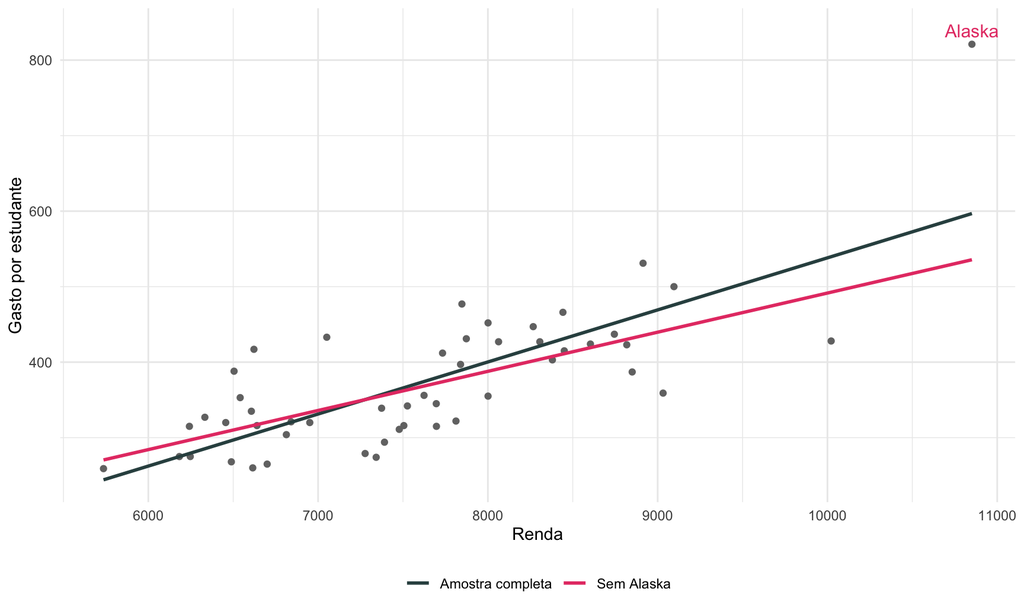

A exclusão de Alaska reduz em cerca de 25% o coeficiente estimado de `Income`. Isso evidencia sua influência, mas não justifica sua exclusão da amostra.

## Resíduo, alavancagem e influência

> **Um resíduo muito incomum significa necessariamente que a observação exerce grande influência sobre a regressão?**

Não necessariamente.

- um **resíduo studentizado grande** indica que $y_i$ está muito distante do valor ajustado pelo modelo;
- **alta alavancagem** indica que os valores das variáveis explicativas da observação são incomuns em relação aos demais valores da amostra;
- uma observação é **influente** quando sua retirada altera de forma importante os coeficientes estimados ou os valores ajustados.

Ser uma observação incomum não é suficiente para ser influente: influência é definida pela mudança que sua retirada provoca na regressão.

## Quando uma observação é sinalizada

Os diagnósticos indicam observações que merecem investigação.

1. verifique possíveis erros de registro ou processamento;
2. compreenda o contexto econômico da observação;
3. avalie a sensibilidade das conclusões à sua presença;
4. relate o que muda com e sem o caso.

Os diagnósticos orientam a investigação; não autorizam a exclusão automática.

## Limitações dos diagnósticos de exclusão

Os diagnósticos *delete-one* são úteis para identificar observações que merecem investigação, mas têm limitações (Kleiber e Zeileis, 2008).

No modelo linear, esses diagnósticos **não exigem reestimar (n) regressões separadamente**: as medidas *leave-one-out* podem ser obtidas por expressões algébricas a partir do ajuste original.

A dificuldade é principalmente substantiva:

- várias observações incomuns podem **mascarar umas às outras**;
- com muitas variáveis explicativas, a inspeção gráfica torna-se menos útil;
- identificar sensibilidade não altera o fato de que o MQO pode ser fortemente afetado por observações incomuns.

Diagnosticar sensibilidade e reduzir sensibilidade são problemas diferentes.

Isso motiva métodos de estimação concebidos para serem menos sensíveis a observações incomuns.

Regressão robusta

## Regressão robusta

Os diagnósticos mostram **quando o ajuste é sensível**, mas não tornam o estimador menos sensível às observações incomuns.

Nesta parte, **regressão robusta** significa **regressão resistente**: métodos de estimação concebidos para que uma pequena parcela de observações incomuns não domine o ajuste (Kleiber e Zeileis, 2008).

- Regressão robusta modifica o procedimento usado para estimar os coeficientes.
- Erros-padrão robustos mantêm os coeficientes de MQO e modificam a estimação de sua incerteza.

Esses dois usos de “robusto” respondem a problemas diferentes.

## Ponto de quebra

O **ponto de quebra** mede a fração de observações que pode ser contaminada antes que um estimador possa assumir valores arbitrariamente distantes.

### Média

Uma única observação suficientemente extrema pode levar a média arbitrariamente longe.

Ponto de quebra: $\mathbf{1/n}$

### Mediana

É preciso contaminar aproximadamente metade da amostra para deslocar a mediana arbitrariamente longe.

Ponto de quebra: $\mathbf{\approx 50\%}$

Quanto maior o ponto de quebra, maior a resistência do estimador à contaminação.

Estimadores podem, portanto, apresentar sensibilidades muito diferentes dependendo do **critério de estimação** utilizado.

## Estimação-M

O MQO utiliza um **critério de estimação** específico: minimizar a soma das perdas quadráticas.

$$\hat\beta_{MQO}
=
\arg\min_\beta \sum_i e_i^2.$$

Uma **função de perda** associa a cada resíduo uma penalização. Essa penalização determina quanto a observação contribui para o critério que será minimizado.

Na **M-estimação** (Huber, 1964), generalizamos o critério escolhendo uma função de perda $\rho$:

$$\hat\beta_M
=
\arg\min_\beta
\sum_i \rho\left(\frac{e_i}{s}\right),$$

em que $s$ mede a escala dos resíduos.

Escolhas robustas de $\rho$ fazem resíduos muito grandes contribuírem menos para o critério do que na perda quadrática, reduzindo sua capacidade de dominar o ajuste.

A M-estimação fornece a ideia básica; o procedimento robusto usado adiante combina etapas adicionais.

## Funções de perda

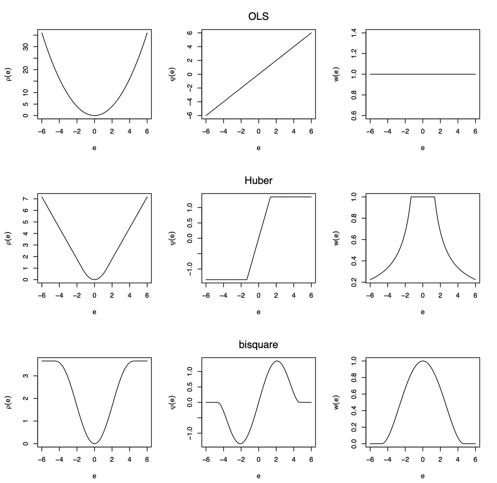

Linhas: MQO (OLS), Huber e bisquare; colunas: função de perda $\rho(e)$, função $\psi(e)$ e peso $w(e)$. O foco neste momento é a primeira coluna: a perda quadrática do MQO cresce rapidamente com $|e|$; Huber limita esse crescimento nas caudas; e bisquare apresenta perda limitada. As demais colunas mostram, qualitativamente, como essas escolhas se refletem em $\psi(e)$ e nos pesos. Huber e bisquare são exemplos didáticos, não a função usada posteriormente em KS2014.

## Pesos e IRLS

Na M-estimação, considere o resíduo padronizado

$$u_i=\frac{e_i}{s}.$$

A função de perda determina a função $\psi$ e os pesos associados:

$$\psi(u)=\frac{d\rho(u)}{du},
\qquad
w(u)=\frac{\psi(u)}{u},$$

com $w(0)$ definido por continuidade.

Em escolhas robustas usuais, valores grandes de $|u_i|$ recebem pesos menores.

Para uma **etapa M**, tomando a escala $s$ como dada, uma atualização dos coeficientes é obtida por mínimos quadrados ponderados:

$$\hat\beta^{(t)}
=
\left(X'W^{(t-1)}X\right)^{-1}
X'W^{(t-1)}y,$$

em que

$$W^{(t-1)}
=
\operatorname{diag}
\left[
w\!\left(u_1^{(t-1)}\right),
\ldots,
w\!\left(u_n^{(t-1)}\right)
\right].$$

## Pesos e IRLS

Os pesos não são conhecidos previamente, pois dependem dos resíduos, que dependem dos próprios coeficientes estimados.

Por isso, a estimação é realizada iterativamente:

$$\hat\beta^{(0)}
\longrightarrow
u^{(0)}
\longrightarrow
W^{(0)}
\longrightarrow
\hat\beta^{(1)}
\longrightarrow
u^{(1)}
\longrightarrow
W^{(1)}
\longrightarrow
\cdots$$

A cada iteração:

1. calculamos os resíduos padronizados;
2. atualizamos os pesos;
3. reestimamos os coeficientes por mínimos quadrados ponderados.

Esse procedimento é denominado **mínimos quadrados reponderados iterativamente** (*iteratively reweighted least squares*, IRLS).

IRLS descreve a lógica computacional de uma **etapa M**. Em `lmrob(..., setting = "KS2014")`, essas etapas integram o procedimento mais amplo $S \rightarrow M \rightarrow D \rightarrow M$.

## Alta alavancagem

M-estimadores cuja resistência depende apenas da **magnitude dos resíduos** podem ainda ser vulneráveis a observações de alta alavancagem.

- Uma observação com uma combinação incomum de valores das variáveis explicativas pode deslocar o ajuste em sua direção.
- Quando isso ocorre, seu próprio resíduo pode permanecer relativamente pequeno, apesar de sua influência potencial sobre o ajuste.

Robustez a resíduos extremos não implica automaticamente robustez a alta alavancagem.

## Alto ponto de quebra e eficiência

Em regressão, M-estimadores baseados apenas nos resíduos **não garantem alto ponto de quebra**.

Os **estimadores MM** (Yohai, 1987) combinam dois objetivos:

- alta resistência à contaminação, partindo de uma estimativa de alto ponto de quebra;
- alta eficiência sob o modelo normal de referência, refinando posteriormente a estimação.

Resistência inicial e eficiência cumprem papéis distintos na construção do estimador.

## `robustbase` e `lmrob()`

O pacote `robustbase` reúne métodos de **estatística robusta**, incluindo regressão linear.

Na aula, utilizaremos:

```r
robustbase::lmrob(..., setting = "KS2014")
```

Com `setting = "KS2014"` (Koller e Stahel, 2017), `lmrob()` utiliza uma estratégia de estimação em **várias etapas**, baseada na arquitetura SMDM.

## Arquitetura SMDM

A construção **MM** parte de uma estimativa S altamente resistente e a refina por M-estimação (Yohai, 1987).

Na configuração `KS2014`, `lmrob()` utiliza a sequência SMDM (Koller e Stahel, 2011; Koller e Stahel, 2017):

$$\mathrm{S}
\;\longrightarrow\;
\mathrm{M}
\;\longrightarrow\;
\mathrm{D}
\;\longrightarrow\;
\mathrm{M}.$$

- **S:** estimativa inicial de alto ponto de quebra.
- **M:** primeiro refinamento dos coeficientes.
- **D:** atualização da escala (*Design Adaptive Scale*).
- **M:** refinamento final dos coeficientes usando a escala atualizada.

## Dados `OECDGrowth`

O conjunto `OECDGrowth`, do pacote `AER`, contém dados de **22 países da OCDE** usados por Nonneman e Vanhoudt (1996) em regressões de crescimento.

Para o modelo utilizado na aula:

- `gdp60` e `gdp85`: PIB real por pessoa em idade ativa, em 1960 e 1985, a preços internacionais de 1985;
- `invest`: média anual da razão entre investimento doméstico real e PIB real, entre 1960 e 1985;
- `popgrowth`: crescimento populacional anual entre 1960 e 1985.

## Modelo de Solow

Consideramos a especificação do modelo de Solow utilizada por Kleiber e Zeileis (2008):

$$\begin{aligned}
\log\left(\frac{\mathrm{gdp85}}{\mathrm{gdp60}}\right)
={}&
\beta_0
+\beta_1\log(\mathrm{gdp60})
+\beta_2\log(\mathrm{invest})\\
&+\beta_3\log(\mathrm{popgrowth}+0{,}05)
+\varepsilon.
\end{aligned}$$

- A variável dependente mede a **variação logarítmica do PIB real** entre 1960 e 1985.
- `gdp60` representa o PIB inicial; `invest`, a acumulação de capital físico; e `popgrowth`, o crescimento populacional.
- O acréscimo de `0,05` segue a especificação adotada para considerar o **crescimento da produtividade do trabalho** (Kleiber e Zeileis, 2008).

## Especificação e MQO em R

```r
# carrega os dados usados no exemplo
data("OECDGrowth", package = "AER")

# define uma única especificação para comparar os procedimentos de estimação
formula_solow <- log(gdp85 / gdp60) ~ log(gdp60) + log(invest) + log(popgrowth + 0.05)

# estima o modelo por mínimos quadrados ordinários
solow_lm <- lm(formula_solow, data = OECDGrowth)
```

## Estimação robusta em R

```r
# estima a mesma especificação com o procedimento robusto
solow_robusta <- robustbase::lmrob(
  formula_solow,
  data = OECDGrowth,
  setting = "KS2014"
)
```

MQO e `lmrob()` usam a mesma especificação. O que muda é o **procedimento de estimação**.

## Inferência com `lmrob()`

Os principais resultados inferenciais podem ser obtidos diretamente do objeto estimado:

```r
# coeficientes, erros-padrão, estatísticas t e valores-p
summary(solow_robusta)
```

```
Call:
robustbase::lmrob(formula = formula_solow, data = OECDGrowth, setting = "KS2014")
 \--> method = "SMDM"
Residuals:
     Min       1Q   Median       3Q      Max
-0.14996 -0.03247 -0.00339  0.03791  0.39006

Coefficients:
                      Estimate Std. Error t value  Pr(>|t|)
(Intercept)             2.1822     0.9175    2.38     0.029 *
log(gdp60)             -0.3226     0.0497   -6.49 0.0000042 ***
log(invest)             0.4977     0.1838    2.71     0.014 *
log(popgrowth + 0.05)  -0.7164     0.2549   -2.81     0.012 *
---
Signif. codes:  0 '***' 0.001 '**' 0.01 '*' 0.05 '.' 0.1 ' ' 1

Robust residual standard error: 0.115
Multiple R-squared:  0.755, Adjusted R-squared:  0.714
Convergence in 13 IRWLS iterations

Robustness weights:
 16 weights are ~= 1. The remaining 6 ones are
     Canada         USA       Japan      Norway      Turkey New Zealand
      0.655       0.992       0.274       0.996       0.974       0.960
Algorithmic parameters:
      tuning.chi1       tuning.chi2       tuning.chi3       tuning.chi4
 -0.5000000000000   1.5000000000000                NA   0.5000000000000
               bb       tuning.psi1       tuning.psi2       tuning.psi3
  0.5000000000000  -0.5000000000000   1.5000000000000   0.9500000000000
      tuning.psi4        refine.tol           rel.tol         scale.tol
               NA   0.0000001000000   0.0000001000000   0.0000000001000
        solve.tol          zero.tol       eps.outlier             eps.x
  0.0000001000000   0.0000000001000   0.0045454545455   0.0000000000176
warn.limit.reject warn.limit.meanrw
  0.5000000000000   0.5000000000000
     nResample         max.it       best.r.s       k.fast.s          k.max
          1000            500             20              2           2000
   maxit.scale      trace.lev            mts     compute.rd      numpoints
           200              0           1000              0             10
fast.s.large.n
          2000
              setting                   psi           subsampling
             "KS2014"                 "lqq"         "nonsingular"
                  cov compute.outlier.stats
            ".vcov.w"                "SMDM"
seed : int(0)
```

## Inferência com `lmrob()`

```r
# intervalos de confiança de 95%
confint(solow_robusta)
```

```
                         2.5 %   97.5 %
(Intercept)            0.25451  4.10984
log(gdp60)            -0.42692 -0.21818
log(invest)            0.11145  0.88386
log(popgrowth + 0.05) -1.25184 -0.18087
```

## Resultados de `lmrob()`

| Termo | Estimativa | Erro-padrão | Valor-p | IC 95% |
| --- | --- | --- | --- | --- |
| (Intercept) | 2.182 | 0.918 | 0.0287 | [0.255; 4.110] |
| log(gdp60) | -0.323 | 0.050 | <0.001 | [-0.427; -0.218] |
| log(invest) | 0.498 | 0.184 | 0.0144 | [0.111; 0.884] |
| log(popgrowth + 0.05) | -0.716 | 0.255 | 0.0116 | [-1.252; -0.181] |

`summary()` reúne a estimação e sua inferência; `confint()` fornece os intervalos de confiança dos coeficientes.

## Resultados: MQO e `lmrob()`

| Termo | MQO | lmrob (KS2014) |
| --- | --- | --- |
| (Intercept) | 2.976 | 2.182 |
| log(gdp60) | -0.343 | -0.323 |
| log(invest) | 0.650 | 0.498 |
| log(popgrowth + 0.05) | -0.573 | -0.716 |

Os coeficientes **não mudam de forma uniforme** entre os dois procedimentos.

A especificação é a mesma; as diferenças refletem a mudança no procedimento de estimação.

## Pesos robustos

Os pesos de robustez podem ser extraídos diretamente do ajuste:

```r
# extrai os pesos de robustez
pesos_robustos <- weights(solow_robusta, type = "robustness")

# mostra as quatro menores ponderações
round(head(sort(pesos_robustos), 4), 3)
```

```
      Japan      Canada New Zealand      Turkey
      0.274       0.655       0.960       0.974
```

- Peso próximo de 1: pouca redução da contribuição da observação.
- Peso menor: maior redução de sua contribuição no ajuste robusto.

Peso robusto não é probabilidade, percentual de influência nem regra automática de exclusão.

## Interpretação econométrica

A regressão resistente responde a um problema específico: **reduzir a sensibilidade do ajuste a observações incomuns**.

Ela não torna o modelo automaticamente robusto a outros problemas econométricos.

- **Endogeneidade:** se $E(\varepsilon_i\mid X_i)\neq 0$, reponderar observações não restaura a exogeneidade dos regressores.
- **Especificação:** regressão resistente não corrige, por si só, problemas como variáveis omitidas, simultaneidade ou forma funcional inadequada.
- **Parâmetro de interesse:** um estimador resistente não necessariamente estima os mesmos parâmetros da média condicional que o MQO.

Baldauf e Santos Silva (2012) mostram que, para o estimador robusto analisado por eles, a combinação de **heterocedasticidade e assimetria dos erros** pode levar à inconsistência para os parâmetros da média condicional.

Esse resultado não é uma demonstração específica sobre `lmrob(..., setting = "KS2014")`.

Robustez a observações incomuns e validade econométrica são questões distintas.

## Regressão robusta

- O MQO pode ser sensível a observações incomuns.
- Procedimentos resistentes modificam a estimação para reduzir essa sensibilidade.
- `lmrob()` fornece os coeficientes e a inferência correspondentes ao ajuste robusto.
- Os pesos robustos ajudam a compreender como as observações contribuíram para o ajuste.
- A escolha do estimador continua exigindo interpretação econométrica.

Na **regressão quantílica**, a função de perda também muda, mas com outro objetivo: estimar diferentes **quantis condicionais de $Y$**.

## Aplicações de regressão robusta em Finanças

### Internacionais

- **Knez & Ready (1997)**  
  [*On the Robustness of Size and Book-to-Market in Cross-Sectional Regressions*](https://doi.org/10.1111/j.1540-6261.1997.tb01113.x)  
  Tamanho, *book-to-market* e sensibilidade dos resultados a observações extremas.
- **Martin & Xia (2022)**  
  [*Efficient bias robust regression for time series factor models*](https://doi.org/10.1057/s41260-022-00258-0)  
  CAPM e modelos multifatoriais estimados com regressão robusta.
- **He, Hao & Zhang (2021)**  
  [*Forecasting stock return volatility using a robust regression model*](https://doi.org/10.1002/for.2779)  
  Perda de Huber na previsão da volatilidade dos retornos acionários.

### Brasil e produção brasileira

- **Maestri & Malaquias (2018)**  
  [*Aspectos do gestor, alocação de carteiras e desempenho de fundos no Brasil*](https://doi.org/10.1590/1808-057x201804590)  
  Fundos multimercados brasileiros e regressão robusta com estimador MM.
- **Aronne, Grossi & Bressan (2020)**  
  [*Identifying outliers in asset pricing data with a new weighted forward search estimator*](https://doi.org/10.1590/1808-057x201909620)  
  *Outliers* em modelos de precificação de ativos, incluindo CAPM e Fama–French.
- **Tomaz, Laurini & Morales (2026)**  
  [*Carbon risk premium in the Brazilian stock market*](https://doi.org/10.1080/20430795.2026.2674943)  
  Prêmio de risco de carbono no mercado acionário brasileiro e M-estimadores.

Regressão quantílica

## Média e quantis condicionais

Na regressão linear estimada por MQO, modelamos a **média condicional** de $Y$ (Brooks, 2019):

$$E(Y\mid X)=X'\beta.$$

A regressão quantílica modela, para cada $\tau$, uma posição da distribuição de $Y$ condicionada aos valores de $X$:

$$Q_\tau(Y\mid X)=X'\beta_\tau,
\qquad 0<\tau<1.$$

Um quantil localiza uma posição da distribuição condicional:

- $\tau=0{,}10$: cerca de 10% da distribuição condicional encontra-se abaixo desse valor e 90% acima;
- $\tau=0{,}50$: mediana condicional;
- $\tau=0{,}90$: cerca de 90% da distribuição condicional encontra-se abaixo desse valor e 10% acima.

## Média, mediana e quantis

A passagem da média aos quantis pode ser vista como uma mudança no critério de minimização (Brooks, 2019; Koenker e Hallock, 2001):

$$\arg\min_m\sum_i (y_i-m)^2
\quad\longrightarrow\quad
\text{média},$$

$$\arg\min_m\sum_i |y_i-m|
\quad\longrightarrow\quad
\text{mediana}.$$

Na mediana, a perda absoluta é **simétrica**: desvios de mesma magnitude acima ou abaixo recebem a mesma penalização.

Para estimar outros quantis, quebramos essa simetria e atribuímos pesos diferentes aos desvios positivos e negativos.

## Por que a perda é assimétrica?

Considere um valor candidato $q$ e o desvio

$$u_i=y_i-q.$$

- $u_i<0$: a observação está **abaixo** de $q$;
- $u_i>0$: a observação está **acima** de $q$.

Para a **mediana**, queremos uma posição central: desvios acima e abaixo recebem a mesma penalização.

Para $\tau=0{,}10$, queremos uma posição mais baixa, com cerca de 10% da distribuição abaixo de $q$. Por isso:

$$\underbrace{u_i<0}_{\text{abaixo de }q}
\;\longrightarrow\;
\text{penalização }0{,}90,
\qquad
\underbrace{u_i>0}_{\text{acima de }q}
\;\longrightarrow\;
\text{penalização }0{,}10.$$

Se $q$ estiver **alto demais**, haverá muitos desvios negativos, fortemente penalizados, e o critério favorece um valor menor de $q$.

Não há um sinal de resíduo “melhor”: a assimetria desloca o mínimo para o **quantil desejado**, usando todas as observações.

## Função de perda quantílica

Defina

$$u_i=y_i-x_i'\beta.$$

A perda quantílica é

$$\rho_\tau(u)=
\begin{cases}
\tau u, & u\geq 0,\\
(\tau-1)u, & u<0.
\end{cases}$$

- Resíduos positivos recebem peso $\tau$.
- Resíduos negativos recebem peso $1-\tau$.
- Para $\tau=0{,}50$, os pesos são simétricos; nos demais quantis, são assimétricos.

## Problema de minimização

Para cada quantil $\tau$, procuramos o vetor $k\times 1$ de coeficientes $\hat\beta_\tau$ que **minimiza a soma dos desvios absolutos assimetricamente penalizados** (Brooks, 2019):

$$\begin{aligned}
\hat\beta_\tau
=
\arg\min_\beta
\Bigg[
&\sum_{i:y_i>x_i'\beta}
\tau\,|y_i-x_i'\beta| \\
&+
\sum_{i:y_i<x_i'\beta}
(1-\tau)\,|y_i-x_i'\beta|
\Bigg].
\end{aligned}$$

A expressão separa as observações de acordo com o sinal do resíduo $u_i=y_i-x_i'\beta$:

- $u_i>0$: $y_i$ está **acima** do valor ajustado e o desvio recebe o fator de penalização $\tau$;
- $u_i<0$: $y_i$ está **abaixo** do valor ajustado e o desvio recebe o fator $1-\tau$.

## Problema de minimização

Assim, $\arg\min_\beta$ seleciona o vetor de coeficientes que produz o menor valor desse critério. Para $\tau=0{,}50$, as penalizações são simétricas; nos demais quantis, a assimetria determina a posição do ajuste.

Como a função objetivo é **convexa e linear por partes**, o problema pode ser formulado como **programação linear**. A regressão quantílica também pode ser formulada por **condições de momento** e estimada no arcabouço de **GMM** (Brooks, 2019).

## Modelo e coeficientes

O modelo linear para o quantil condicional $\tau$ é

$$Q_\tau(Y\mid X)=X'\beta_\tau.$$

O coeficiente $\beta_{j,\tau}$ representa a associação entre $x_j$ e o quantil condicional $\tau$ de $Y$, mantidos os demais regressores constantes.

Assim, diferentes valores de $\tau$ permitem examinar se essa associação muda ao longo da distribuição condicional de $Y$.

## O que regressão quantílica não é

Para estimar $Q_{0,10}(Y\mid X)$, não devemos (Brooks, 2019):

1. ordenar $Y$;
2. selecionar os 10% menores valores observados de $Y$;
3. estimar uma regressão nessa subamostra.

Esse procedimento equivaleria a **truncar a variável dependente** e poderia introduzir viés de seleção amostral.

Cada regressão quantílica utiliza todas as observações da amostra.

$\tau=0{,}10$ indica um quantil condicional, não uma subamostra formada pelos 10% menores valores de $Y$.

## Ford e S&P 500

A aplicação segue o exemplo de CAPM de Wichmann e Brooks (2019).

$$(R_F-r_f)_t
=
\alpha+\beta(R_M-r_f)_t+u_t.$$

- Variável resposta: retorno excedente da Ford.
- Regressor: retorno excedente do S&P 500.
- Benchmark: CAPM estimado por MQO.

A sensibilidade estimada do retorno excedente da Ford ao mercado permanece a mesma em diferentes quantis condicionais?

## Retornos excedentes

Para estimar o CAPM, transformamos os preços em retornos logarítmicos mensais e calculamos os retornos excedentes:

```r
# Calcule os retornos logarítmicos mensais em porcentagem
dados_capm_retornos <- dados_capm |>
  mutate(
    ret_sp500 = c(NA, 100 * diff(log(SANDP))),
    ret_ford = c(NA, 100 * diff(log(FORD)))
  )

# Converta a taxa livre de risco para a base mensal e calcule os retornos excedentes
dados_capm_retexc <- dados_capm_retornos |>
  mutate(
    ustb3m = USTB3M / 12,
    retexc_sp500 = ret_sp500 - ustb3m,
    retexc_ford = ret_ford - ustb3m
  ) |>
  drop_na()
```

Assim, a regressão utiliza retornos excedentes:

$$R^e=R-r_f.$$

## CAPM por MQO

Primeiro, estimamos a relação de referência por MQO:

```r
# Estime o CAPM por MQO para obter a relação de referência
capm_ford <- lm(
  retexc_ford ~ retexc_sp500,
  data = dados_capm_retexc
)

# Obtenha o resumo do modelo
summary(capm_ford)
```

Para estes dados,

$$\hat\alpha_{MQO}\approx-0{,}956,
\qquad
\hat\beta_{MQO}\approx1{,}890.$$

A regressão descreve a relação entre os retornos excedentes da Ford e do mercado para a **média condicional**.

## Regressão da mediana

`rq()` utiliza uma estrutura semelhante a `lm()`: especificamos a fórmula e os dados, e o argumento `tau` indica o quantil de interesse (Wichmann e Brooks, 2019).

```r
# Estime a mediana condicional do retorno excedente da Ford
rq_ford_mediana <- quantreg::rq(
  retexc_ford ~ retexc_sp500,
  data = dados_capm_retexc
)

# Examine os resultados da regressão quantílica
summary(rq_ford_mediana)
```

```
Call: quantreg::rq(formula = retexc_ford ~ retexc_sp500, data = dados_capm_retexc)

tau: [1] 0.5

Coefficients:
             coefficients lower bd upper bd
(Intercept)  -1.48968     -2.37032 -0.54627
retexc_sp500  1.43846      1.06695  1.83852
```

Quando `tau` não é especificado, o valor padrão é

$$\tau=0{,}50,$$

isto é, estimamos a **mediana condicional**.

## Regressão em diferentes quantis

`rq()` aceita também um **vetor de valores de `tau`**. Assim, podemos estimar os nove decis em uma única chamada (Wichmann e Brooks, 2019):

```r
# Estime regressões para os quantis de 0,10 a 0,90
rq_ford_decis <- quantreg::rq(
  retexc_ford ~ retexc_sp500,
  data = dados_capm_retexc,
  tau = seq(0.1, 0.9, 0.1)
)

# Examine os resultados para os nove quantis estimados
summary(rq_ford_decis)
```

```
Call: quantreg::rq(formula = retexc_ford ~ retexc_sp500, tau = seq(0.1,
    0.9, 0.1), data = dados_capm_retexc)

tau: [1] 0.1

Coefficients:
             coefficients lower bd upper bd
(Intercept)  -11.9291     -13.0959  -9.4002
retexc_sp500   2.3404       1.2091   2.5840

Call: quantreg::rq(formula = retexc_ford ~ retexc_sp500, tau = seq(0.1,
    0.9, 0.1), data = dados_capm_retexc)

tau: [1] 0.2

Coefficients:
             coefficients lower bd upper bd
(Intercept)  -7.3496      -8.7416  -6.0859
retexc_sp500  1.8044       1.3317   2.0607

Call: quantreg::rq(formula = retexc_ford ~ retexc_sp500, tau = seq(0.1,
    0.9, 0.1), data = dados_capm_retexc)

tau: [1] 0.3

Coefficients:
             coefficients lower bd upper bd
(Intercept)  -4.8783      -5.9999  -4.0628
retexc_sp500  1.6596       1.4072   2.0448

Call: quantreg::rq(formula = retexc_ford ~ retexc_sp500, tau = seq(0.1,
    0.9, 0.1), data = dados_capm_retexc)

tau: [1] 0.4

Coefficients:
             coefficients lower bd upper bd
(Intercept)  -3.3479      -4.4147  -1.8955
retexc_sp500  1.5005       1.1955   1.8848

```

[output cut: 34 more lines]

```

Coefficients:
             coefficients lower bd upper bd
(Intercept)  4.0013       2.5742   6.2119
retexc_sp500 1.6199       1.1847   2.0255

Call: quantreg::rq(formula = retexc_ford ~ retexc_sp500, tau = seq(0.1,
    0.9, 0.1), data = dados_capm_retexc)

tau: [1] 0.9

Coefficients:
             coefficients lower bd upper bd
(Intercept)  10.45627      7.53227 14.67108
retexc_sp500  1.84733      0.70219  2.28393
```

## Coeficientes nos decis

| tau | Intercepto | Mercado |
| --- | --- | --- |
| 0.1 | -11.929 | 2.340 |
| 0.2 | -7.350 | 1.804 |
| 0.3 | -4.878 | 1.660 |
| 0.4 | -3.348 | 1.501 |
| 0.5 | -1.490 | 1.438 |
| 0.6 | -0.019 | 1.297 |
| 0.7 | 1.757 | 1.528 |
| 0.8 | 4.001 | 1.620 |
| 0.9 | 10.456 | 1.847 |

No primeiro decil ($\tau=0{,}10$), a inclinação estimada é maior que na mediana ($\tau=0{,}50$), um resultado que será retomado na interpretação financeira de Wichmann e Brooks (2019).

## Retas quantílicas

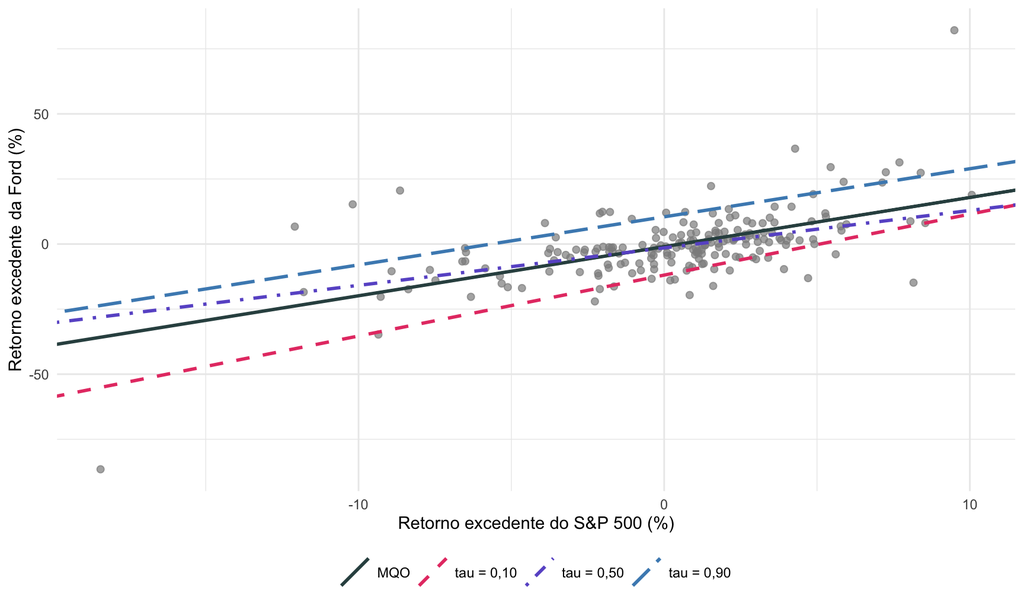

As retas usam a mesma amostra; o valor de $\tau$ muda o quantil condicional estimado, não o subconjunto de observações.

## Coeficientes ao longo dos quantis

O *R Guide* compara os coeficientes das regressões quantílicas com o *benchmark* de MQO:

```r
# calcula ICs de 95% para os coeficientes quantílicos e compara com o MQO
plot(
  summary(rq_ford_decis, alpha = 0.05),
  level = 0.95
)
```

- **Preto:** estimativas dos coeficientes quantílicos.
- **Cinza:** intervalos de confiança de 95% das estimativas quantílicas.
- **Vermelho:** estimativa de MQO e seu intervalo de confiança de 95%.

## Coeficientes ao longo dos quantis

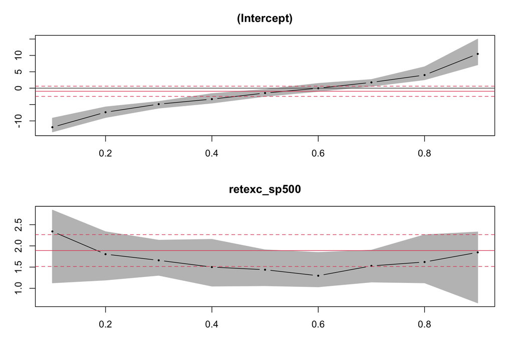

Estimativas do intercepto (painel superior) e do beta da Ford (painel inferior) ao longo dos quantis de 0,10 a 0,90. Em preto, estimativas quantílicas e respectivos intervalos de confiança de 95% em cinza; em vermelho, estimativa por MQO e seu intervalo de confiança de 95%. O intercepto aumenta ao longo dos quantis, enquanto o beta é particularmente elevado no primeiro decil, diminui nos quantis centrais e volta a crescer nos quantis superiores.

## Interpretação financeira

Para $\tau=0{,}10$,

$$\hat\beta_{0,10}\approx2{,}34,
\qquad
\hat\beta_{MQO}\approx1{,}89.$$

Uma variação de 1 ponto percentual no retorno excedente do mercado está associada a uma variação de aproximadamente 2,34 pontos percentuais no quantil condicional $0{,}10$ do retorno excedente da Ford.

Assim, a sensibilidade estimada para $\tau=0{,}10$ é maior que a estimada por MQO e que as estimadas nos quantis centrais.

Wichmann e Brooks (2019) interpretam esse padrão como maior **tail systematic risk** da Ford.

## Interpretação financeira

O resultado para $\tau=0{,}10$ mostra uma sensibilidade ao mercado particularmente elevada nesse quantil condicional do retorno da Ford.

Wichmann e Brooks (2019) relacionam esse resultado a um argumento econômico mais amplo: em quedas do mercado, retornos acionários podem apresentar movimentos conjuntos, reduzindo a proteção proporcionada pela diversificação.

Por isso, os autores argumentam que os **benefícios de diversificação** inferidos examinando apenas uma regressão convencional podem ser superestimados.

## Robustez e limitações da regressão quantílica

A regressão quantílica permite modelar diferentes partes de $Y\mid X$, mas **não elimina outros problemas econométricos**.

- **Heterogeneidade condicional:** não precisamos impor dispersão constante. Se as inclinações $\beta_{j,\tau}$ variam com $\tau$, a associação entre $x_j$ e $Y$ não corresponde apenas a um deslocamento comum da distribuição; pode haver mudanças de escala ou de forma (Koenker e Hallock, 2001).
- **Observações extremas:** como a perda cresce linearmente com $|u|$, grandes resíduos verticais têm menor capacidade de dominar o ajuste do que no MQO. Isso, porém, **não elimina problemas de alta alavancagem ou influência** (Koenker e Hallock, 2001).
- **Inferência:** erros-padrão e intervalos de confiança continuam exigindo métodos próprios da regressão quantílica. Heterocedasticidade e, em séries temporais, dependência serial **não são automaticamente resolvidas** pela estimação dos quantis.
- **Endogeneidade:** regressão quantílica convencional não torna um regressor exógeno. Uma interpretação causal continua exigindo uma estratégia de identificação apropriada.

Regressão quantílica muda **qual aspecto de $Y\mid X$ estimamos**; não substitui inferência adequada, diagnóstico de influência nem identificação causal.

## Síntese

| Pergunta | Ferramenta |
| --- | --- |
| Uma observação altera substantivamente o ajuste? | Diagnósticos de influência |
| O ajuste é excessivamente sensível a determinadas observações? | Regressão robusta |
| A associação varia ao longo da distribuição condicional? | Regressão quantílica |

As três ferramentas respondem a perguntas econométricas diferentes.

## Aplicações de regressão quantílica

### Finanças

- **Bassett & Chen (2001)**  
  [*Portfolio style: Return-based attribution using quantile regression*](https://doi.org/10.1007/s001810100074)  
  Exposição de fundos a diferentes estilos de investimento.
- **Engle & Manganelli (2004)**  
  [*CAViaR: Conditional Autoregressive Value at Risk by Regression Quantiles*](https://doi.org/10.1198/073500104000000370)  
  Modelagem dinâmica do risco por meio do VaR condicional.
- **Adrian & Brunnermeier (2016)**  
  [*CoVaR*](https://doi.org/10.1257/aer.20120555)  
  Quantis condicionais aplicados à mensuração do risco sistêmico.

### Outras aplicações

- **Maiti (2021)**  
  [*Quantile regression, asset pricing and investment decision*](https://www.sciencedirect.com/science/article/pii/S0970389621000203)  
  Modelos fatoriais, *asset pricing* e decisões de investimento.
- **Angrist, Chernozhukov & Fernández-Val (2006)**  
  [*Quantile Regression under Misspecification, with an Application to the U.S. Wage Structure*](https://doi.org/10.1111/j.1468-0262.2006.00671.x)  
  Relações econômicas ao longo da distribuição condicional dos salários.
- **Koenker & Bassett (2010)**  
  [*March Madness, Quantile Regression Bracketology, and the Hayek Hypothesis*](https://doi.org/10.1198/jbes.2009.07093)  
  Distribuições preditivas aplicadas ao basquete universitário.

## Aplicações de regressão quantílica no Brasil

### Mercado de capitais e finanças corporativas

- **Silva, Costa Jr. & Armada**  
  [*Avaliação do momentum no Brasil usando regressões quantílicas*](https://www.scielo.br/j/rcf/a/FwTCXjtfqLRqXJqThchTvsk/?lang=pt)  
  Momentum, efeito disposição e retornos de ações brasileiras.
- **Oliveira et al.**  
  [*Determinants of the level of indebtedness for Brazilian firms: A quantile regression approach*](https://www.sciencedirect.com/science/article/pii/S1517758013000179)  
  Determinantes da estrutura de capital em diferentes níveis de endividamento.
- **Rocha & Camargos**  
  [*Decisões de Financiamento e Retornos Anormais: uma Análise de Companhias Brasileiras*](https://www.scielo.br/j/bbr/a/BnJLWPK8YxkVBpGZ7rwvT6m/?lang=pt)  
  Decisões de financiamento e retornos anormais de companhias brasileiras.

### Outras aplicações econômicas e financeiras

- **Souza & Gartner**  
  [*Reação do mercado de ações a eventos de fusões e aquisições bancárias no Brasil*](https://revistas.usp.br/rcf/article/view/156386)  
  Fusões e aquisições bancárias e retornos anormais no mercado acionário.
- **Duarte, Girão & Paulo**  
  [*Avaliando Modelos Lineares de Value Relevance: Eles Captam o que Deveriam Captar?*](https://www.scielo.br/j/rac/a/yyBYJj8wCdvxjZVSnQmX4qw/)  
  Informação contábil e valor de mercado ao longo da distribuição condicional.
- **Silva & Porto Júnior**  
  [*Sistema financeiro e crescimento econômico: uma aplicação de regressão quantílica*](https://revistas.usp.br/ecoa/article/view/930)  
  Desenvolvimento financeiro e crescimento econômico em diferentes quantis.

## Referências

BALDAUF, M.; SANTOS SILVA, J. M. C. [On the Use of Robust Regression in Econometrics](https://doi.org/10.1016/j.econlet.2011.09.031). **Economics Letters**, v. 114, n. 1, p. 124–127, 2012.

BELSLEY, D. A.; KUH, E.; WELSCH, R. E. **Regression Diagnostics: Identifying Influential Data and Sources of Collinearity**. [s.l.] John Wiley & Sons, 1980.

BROOKS, C. **[Introductory Econometrics for Finance](https://doi.org/10.1017/9781108524872)**. 4. ed. Cambridge: Cambridge University Press, 2019.

HILL, R. C.; GRIFFITHS, W. E.; LIM, G. C. **Principles of Econometrics**. 5. ed. Hoboken, NJ: Wiley, 2018.

HUBER, P. J. [Robust Estimation of a Location Parameter](https://doi.org/10.1214/aoms/1177703732). **The Annals of Mathematical Statistics**, v. 35, n. 1, p. 73–101, 1964.

KLEIBER, C.; ZEILEIS, A. **[Applied Econometrics with R](https://doi.org/10.1007/978-0-387-77318-6)**. New York: Springer, 2008.

KOENKER, R.; HALLOCK, K. F. Quantile Regression. **Journal of Economic Perspectives**, v. 15, n. 4, p. 143–156, 2001.

KOLLER, M.; STAHEL, W. A. [Sharpening Wald-type inference in robust regression for small samples](https://doi.org/10.1016/j.csda.2011.02.014). **Computational Statistics & Data Analysis**, v. 55, n. 8, p. 2504–2515, 2011.

KOLLER, M.; STAHEL, W. A. [Nonsingular subsampling for regression S estimators with categorical predictors](https://doi.org/10.1007/s00180-016-0679-x). **Computational Statistics**, v. 32, n. 2, p. 631–646, 2017.

NONNEMAN, W.; VANHOUDT, P. [A Further Augmentation of the Solow Model and the Empirics of Economic Growth for OECD Countries](https://doi.org/10.2307/2946677). **The Quarterly Journal of Economics**, v. 111, n. 3, p. 943–953, 1996.

WICHMANN, R.; BROOKS, C. **R Guide to Accompany Introductory Econometrics for Finance**. 4. ed. [s.l.] The ICMA Centre, Henley Business School, University of Reading, 2019.

YOHAI, V. J. [High Breakdown-Point and High Efficiency Robust Estimates for Regression](https://doi.org/10.1214/aos/1176350366). **The Annals of Statistics**, v. 15, n. 2, p. 642–656, 1987.